# STA207 Hw1 - Eric Kalosa-Kenyon

```r
library("dplyr")
library("plyr")
```

# 19.5

## 19.5.a

```r
raw = c(250, 288, 265, 273, 268, 270, 269, 269)
len = length(raw)
wid = 3
df = data.frame(matrix(rep(NA, len*wid), len, wid))
names(df) = c("val", "A", "B")
df$val = raw
df$A = rep(1:2, 4)
df$B = c(rep(1,2), rep(2,2), rep(3,2), rep(4,2))
udd = sum(raw) / length(raw)
ub = ddply(df,~B,summarise,mean=mean(val))$mean
bet = ub - udd
ua = ddply(df,~A,summarise,mean=mean(val))$mean
alp = ua - udd
```

$\beta = 0, 0, 0, 0$. The nonexistence of the main B factor shows that the average response value doesn’t change with response to B.

## 19.5.b

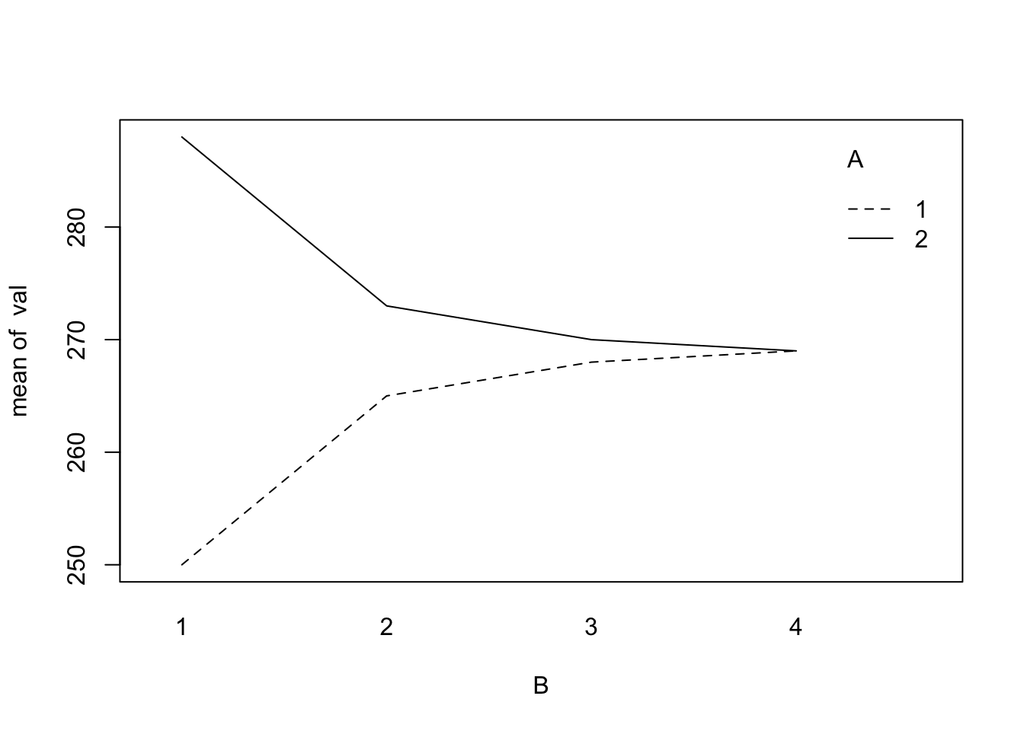

```r
with(df, interaction.plot(B, A, val))
```

There are interaction effects present, as evidenced by the aniparallel lines in the interaction plot. Factor A1 induces a positive relationship between the response variable and factor B, whereas factor A2 induces the opposite relationship between the repsonse and factor B.

## 19.5.c

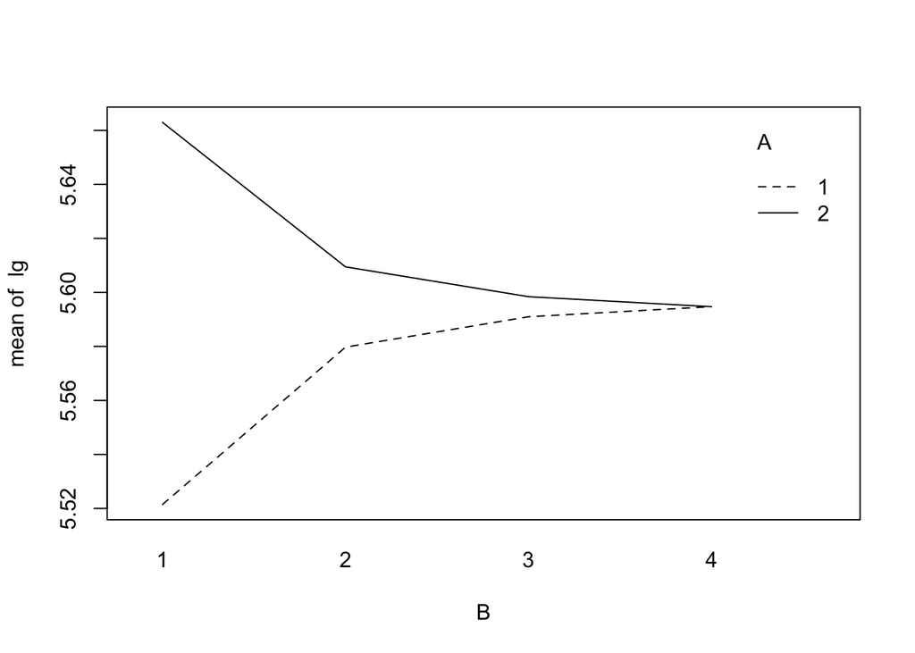

```r
df$lg = log(df$val)
with(df, interaction.plot(B, A, lg))
```

The log transformation of the response variable doesn’t change the interaction plot.

# 19.8

## 19.8.a

```r
sig = 4
n = 6
a = 2
b = 4
E_MSE = sig^2
abij = matrix(df$val - (mean(df$val)), a, b)
for (i in 1:a){
    for (j in 1:b){
        ai = alp[i]
        bj = bet[j]
        abij[i,j] = abij[i,j] - ai - bj
}}
E_MSAB = sig^2 + n *sum((abij)^2) / ((a-1)*(b-1))
```

$E\{MSE\}= 16$ $E\{MSAB\}= 952$

## 19.8.b

$E\{MSAB\} >> \{MSE\}$, and this means that there are interactions present. This is intuitively obvious from the interaction plot.

# 19.18

## 19.18.a

```r
rawkid = read.csv("kidney.csv")
kid = rawkid[c("Days", "Duration", "Weight")]
av_kid = with(kid, aov(Days ~ Duration * Weight))
```

The coefficients of the ANOVA with interaction are $\mu, Dur, Wei, Interact = -6.5666667, 2.8666667, 9.25, -3.3.$ The residuals are -2.25, -0.25, -1.25, 0.75, -2.25, -0.25, -2.25, 2.75, 3.75, 5.75, -6.2, -4.2, -1.2, 3.8, 6.8, -4.2, -5.2, -7.2, -3.2, 11.8, 0.85, -4.15, -6.15, -9.15, 10.85, 1.85, -7.15, 15.85, -11.15, 12.85, -1.8166667, -0.8166667, -0.8166667, -1.8166667, 2.1833333, 0.1833333, 5.1833333, 2.1833333, -1.8166667, 1.1833333, 0.5333333, -1.4666667, -2.4666667, -4.4666667, -3.4666667, -3.4666667, -1.4666667, 1.5333333, 2.5333333, 4.5333333, 2.8833333, 0.8833333, 4.8833333, -4.1166667, -0.1166667, 7.8833333, -3.1166667, 1.8833333, -1.1166667, -6.1166667

## 19.18.b

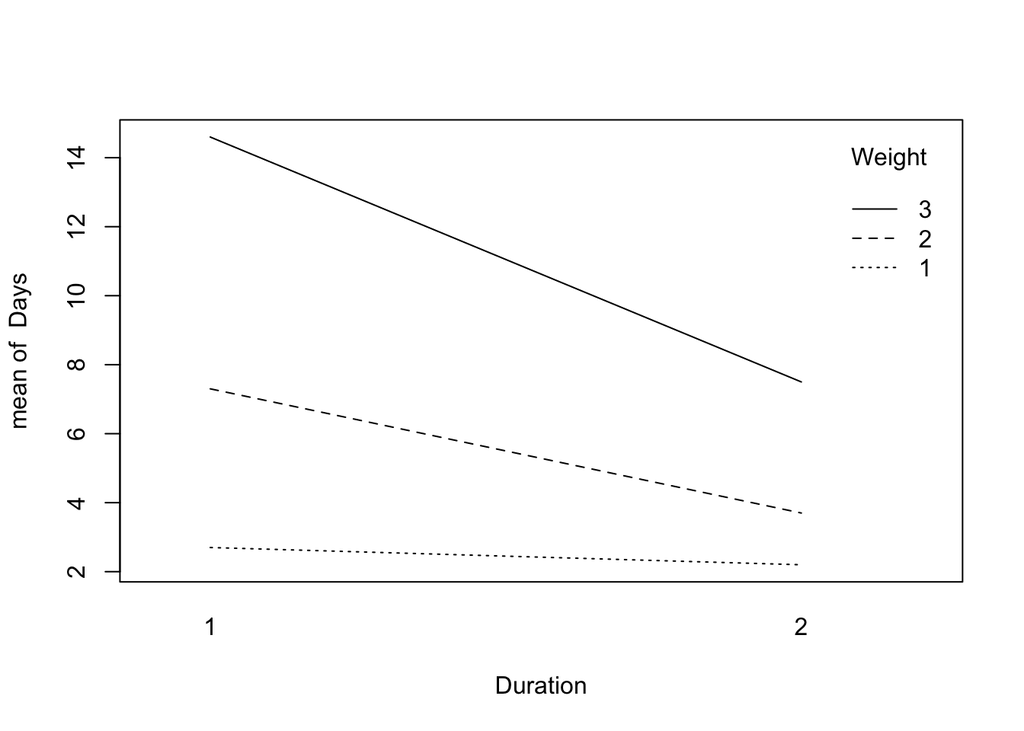

```r
with(kid,  interaction.plot(Duration, Weight, Days))
```

The interaction plot shows that there is a decrease in number of days of hospitalization with an increase in the duration of treatment, and that increasing weight increases the extremity of this relationship. Furthermore increased weight exacerbates the number of days of hospitalization.

## 19.18.c

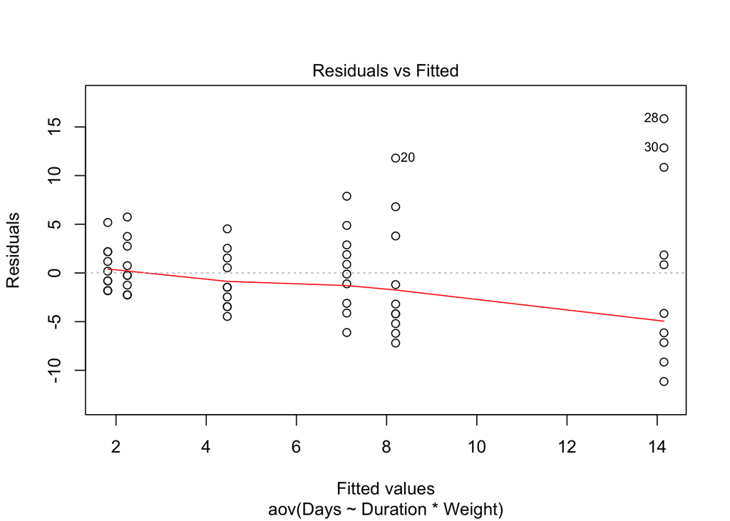

```r
plot(av_kid, 1)
```

```r
av_kid
```

```
## Call:
##    aov(formula = Days ~ Duration * Weight)
##
## Terms:
##                  Duration    Weight Duration:Weight Residuals
## Sum of Squares   209.0667  739.6000        108.9000 1585.7667
## Deg. of Freedom         1         1               1        56
##
## Residual standard error: 5.321397
## Estimated effects may be unbalanced
```

It appears that weight accounts for the majority of the variation outside of the stochastic noise.

```r
summary(av_kid)
```

```
##                 Df Sum Sq Mean Sq F value   Pr(>F)
## Duration         1  209.1   209.1   7.383  0.00874 **
## Weight           1  739.6   739.6  26.118 4.03e-06 ***
## Duration:Weight  1  108.9   108.9   3.846  0.05485 .
## Residuals       56 1585.8    28.3
## ---
## Signif. codes:  0 '***' 0.001 '**' 0.01 '*' 0.05 '.' 0.1 ' ' 1
```

Weight and duration are significant at the $\alpha=0.05$ level. The interaction term is not significant at that level.

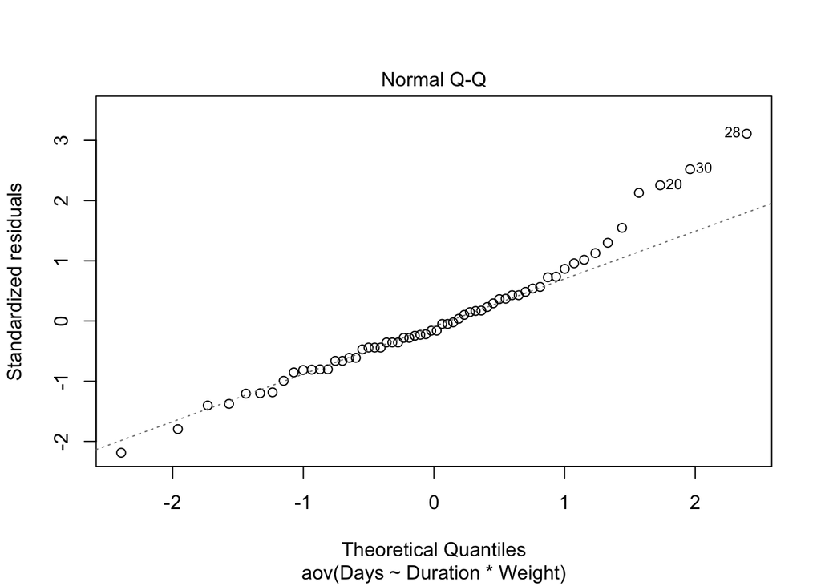

```r
plot(av_kid, 2)
```

The normal-QQ plot has heavy deviations on the right tail, showing that the normality assumption is likely invalid.

# 19.34

## 19.34.a

We saw in the previous problem that interaction effects are not significant at the $\alpha=0.05$ level, so we will exclude them from the model and proceed with an excusively additive model.

```r
kid$log10Days = log(kid$Days+1,10)
a = length(levels(factor(kid$Duration)))
b = length(levels(factor(kid$Weight)))
# Calculate means estimates
ybars = matrix(nrow = a, ncol = b)
for (i in 1:a){
    for (j in 1:b){
        ybars[i,j] = mean(kid[kid$Duration == i & kid$Weight == j,]$log10Days)
    }
}
u22 = ybars[2,2]
# Calculate MSE estimate
ydif = c()
for (i in 1:dim(kid)[1]){
    k = ybars[kid$Duration[i], kid$Weight[i]] - kid$log10Days[i]
    ydif = c(ydif, k)
}
MSE = sum(ydif^2) / ((n-1)*a*b)
s2_hat = MSE/n
alpha = 0.05
t_off = qt(1-alpha/2, (n-1)*a*b)
ci95 = t_off*sqrt(s2_hat)
```

The 95% confidence interval for the estimate of $\mu_{2,2}$ is 0.5809641 +,- 0.3559425.

## 19.34.b

```r
u21 = ybars[2,1]
u23 = ybars[2,3]
```

## 19.34.c

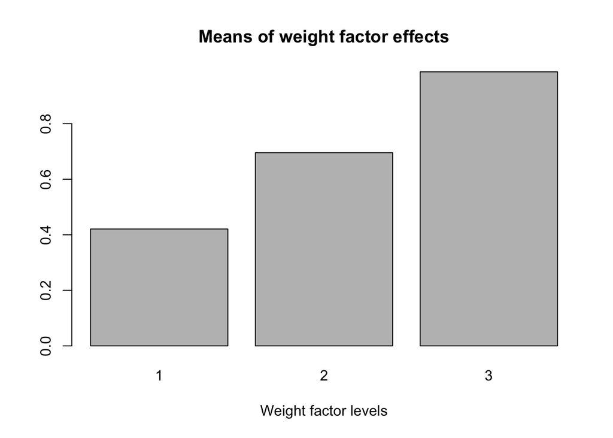

```r
weight_means = (ybars[1,] + ybars[2,])/2
duration_means = (ybars[,1] + ybars[,2] + ybars[,3])/3
barplot(weight_means, main="Means of weight factor effects",
        xlab = "Weight factor levels",
        names.arg=c("1", "2", "3")
    )
```

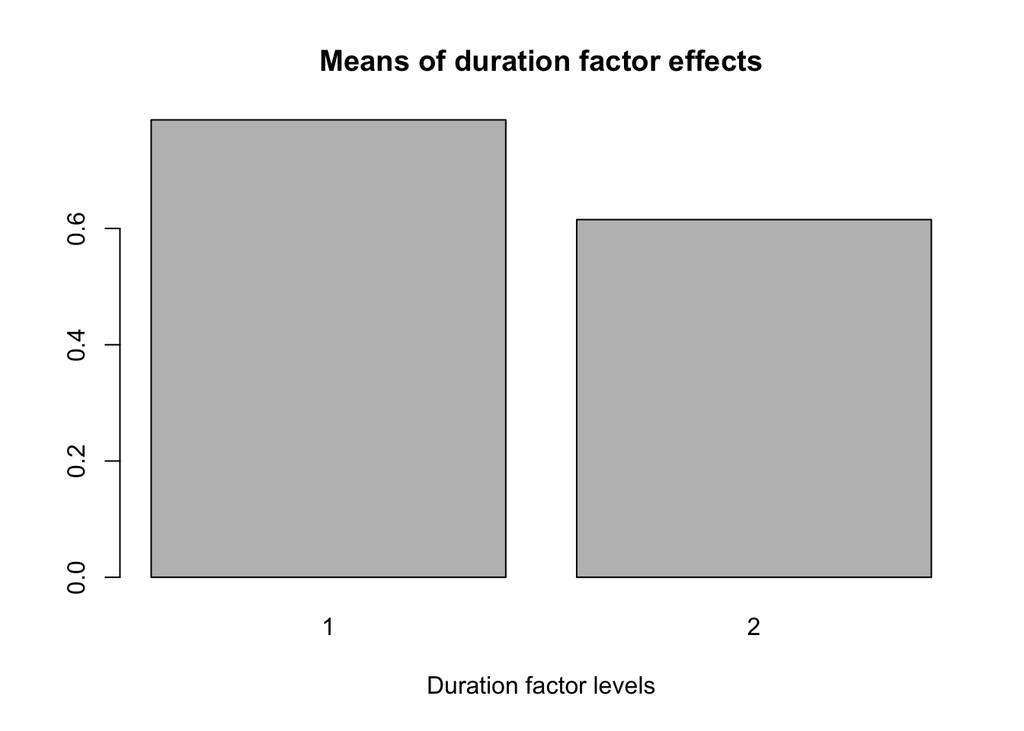

```r
barplot(duration_means, main="Means of duration factor effects",
        xlab = "Duration factor levels",
        names.arg=c("1", "2")
    )
```

## 19.34.d

The best test for a 6-way multiple comparison is Tukey’s test.

# 19.41

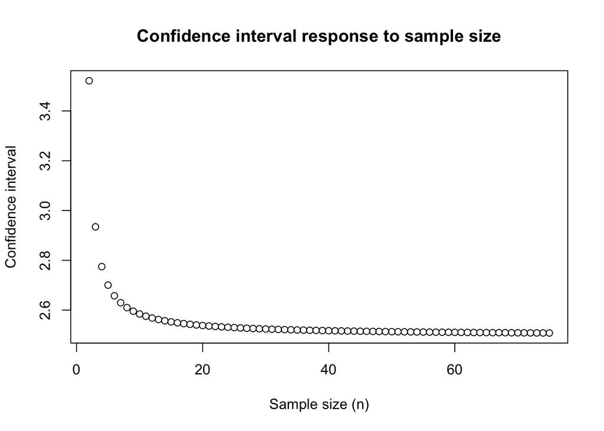

```r
alpha = 0.05
sig = 0.32
ntest = 4
ci_desired = 0.9
prec = 0.2
a = 2
b = 3
n = 2:75
B = qt(1-alpha/(2*ntest), (n-1)*a*b)
plot(n, B, main="Confidence interval response to sample size",
     xlab = "Sample size (n)", ylab="Confidence interval")
abline(h = ci_desired)
```